# Quercus globosa Plastome VCF QC And Filtering Report

Generated 2026-07-14 14:41:08 CDT from `Quercus_globosa_plastome.allsite.allsite.exclude8_2397024510.filtered.variant.vcf.gz`.

Samples

209

Variant records

442

SNPs / indels

304 / 138

Ts/Tv

1.286

## Interpretation

The final VCF contains 442 PASS records across 209 samples. Site missingness remains below the configured 10% filter, but sample-level missingness and plastome heterozygote calls deserve additional review before downstream haplotype or network analyses.

**SNPfiltR status:** SNPfiltR is not installed in this R library, so this report uses vcfR to compute equivalent QC summaries and records the SNPfiltR status for reproducibility.

## Filtering Conditions

These conditions are parsed from the final VCF header and the alloutgroup filtering history.

| Step | Condition | Expression | Source |
| --- | --- | --- | --- |
| 1 | Exclude eight samples | Quercus_414, Quercus_415, Quercus_419, Quercus_422, Quercus_424, Quercus_427, Quercus_433, Quercus_435 | VCF header bcftools_viewCommand and file name exclude8 |
| 2 | Keep reference sites or biallelic SNP/indel sites | N_ALT=0 \|\| (N_ALT=1 && (TYPE="snp" \|\| TYPE="indel")) | VCF header bcftools_viewCommand |
| 3 | Remove sites with >=10% missing genotypes before genotype masking | F_MISSING < 0.10 | VCF header bcftools_viewCommand |
| 4 | Mask low-quality variant-site genotypes to missing | N_ALT>0 & (FMT/DP<10 \| FMT/GQ<30 \| FMT/DP>10000) | VCF header bcftools_pluginCommand setGT |
| 5 | Mask low-quality reference-site genotypes to missing | N_ALT=0 & (FMT/DP<10 \| FMT/RGQ<30 \| FMT/DP>10000) | VCF header bcftools_pluginCommand setGT |
| 6 | Remove sites with >=10% missing genotypes after genotype masking | F_MISSING < 0.10 | VCF header bcftools_viewCommand |
| 7 | Apply GATK-style site hard filters separately to SNPs and indels | SNPs: QD>=2, FS<=60, MQ>=40, MQRankSum>=-12.5, ReadPosRankSum>=-8, SOR<=3; indels: QD>=2, FS<=200, ReadPosRankSum>=-20, SOR<=10 | VCF header bcftools_filterCommand |
| 8 | Keep variant SNP/indel sites for this final variant VCF | N_ALT>0 && (TYPE="snp" \|\| TYPE="indel") | VCF header bcftools_viewCommand |

## Suggestions

- The site-level missingness filter is behaving as expected: the maximum remaining site missingness is 9.57%, below the 10% cutoff.
- 11 samples have more than 10% missing genotypes in this final variant VCF. Inspect these before haplotype or network analysis; if they drive topology, consider a sample-level missingness cutoff or a sensitivity run without them.
- 117 sites have MAF = 0 after genotype masking. For haplotype/network inputs, remove monomorphic records after masking so only informative variation remains.
- The highest site heterozygote rate is 98.56%. Because plastome calls are usually treated as haploid or effectively haploid, inspect high-heterozygosity clusters and consider masking heterozygotes to missing before no-missing haplotype analyses.
- Depth and genotype quality look broadly strong after masking: median DP is 606 and mean GQ is 96.42 across called genotypes. The current DP >= 10, GQ/RGQ >= 30, and DP <= 10000 masks are reasonable for this dataset.

## Plots

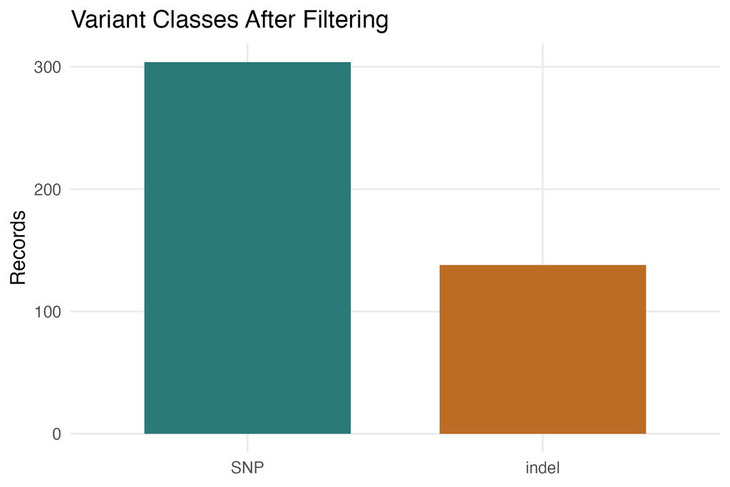

SNP and indel counts retained in the final filtered variant VCF.

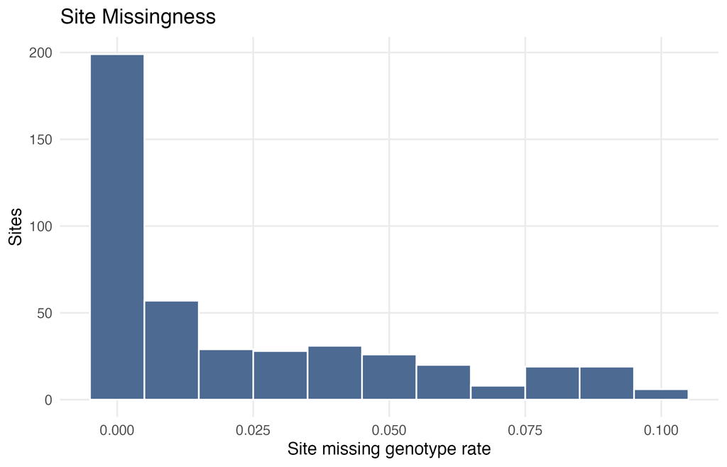

Remaining site missingness after genotype masking and the final missingness filter.

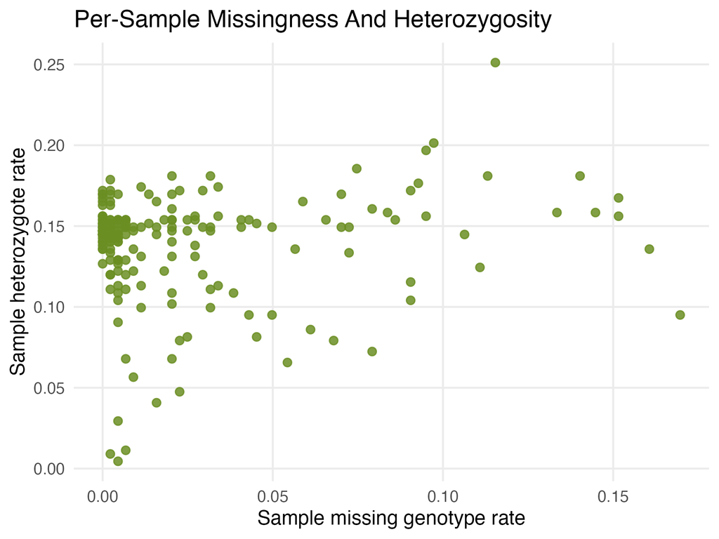

Samples with elevated missingness or heterozygosity are useful targets for sensitivity checks.

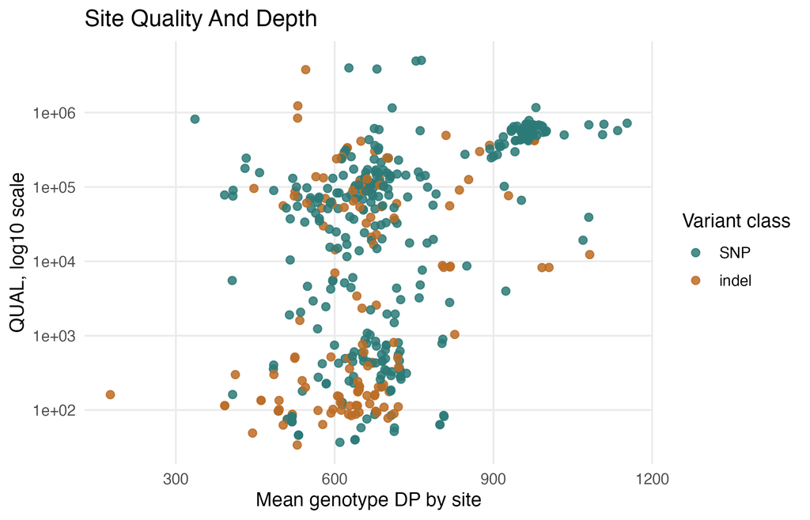

QUAL versus mean site depth; high depths are expected in plastome-enriched data but outliers should still be watched.

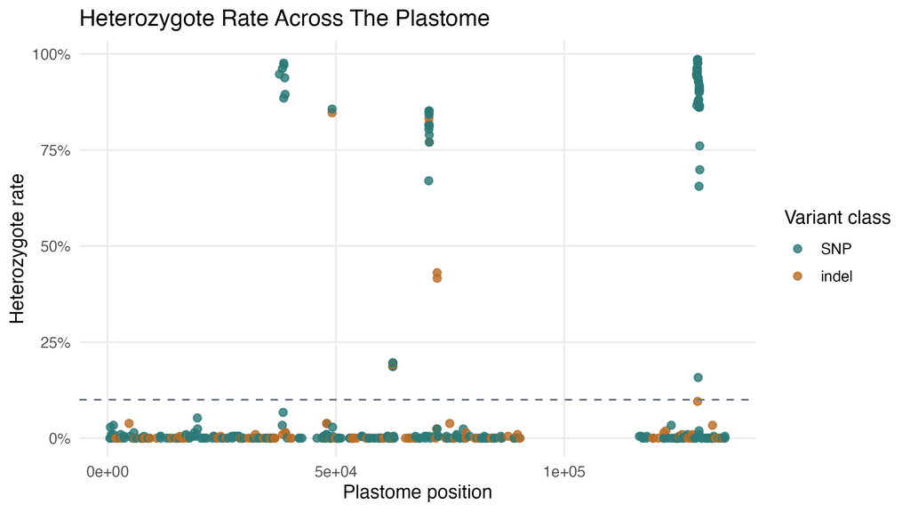

High-heterozygosity clusters are candidates for masking or manual inspection in plastome analyses.

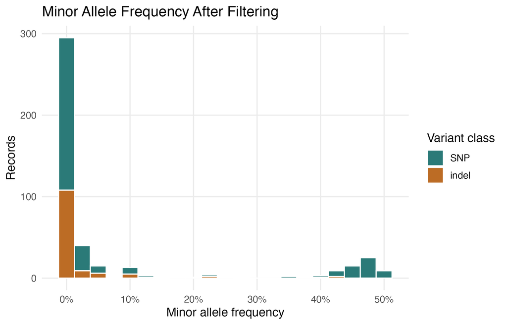

MAF distribution after filtering; MAF = 0 records are not informative after masking.

## QC Summary Table

| Metric | Value |
| --- | --- |
| VCF | Quercus_globosa_plastome.allsite.allsite.exclude8_2397024510.filtered.variant.vcf.gz |
| Generated | 2026-07-14 14:41:08 CDT |
| SNPfiltR installed | FALSE |
| Samples | 209 |
| Variant records | 442 |
| SNP records | 304 |
| Indel records | 138 |
| PASS records | 442 |
| Mean site missing rate | 0.02372 |
| Max site missing rate | 0.09569 |
| Mean sample missing rate | 0.02372 |
| Max sample missing rate | 0.1697 |
| Mean site heterozygote rate | 0.1394 |
| Max site heterozygote rate | 0.9856 |
| Mean DP across called genotypes | 693.6 |
| Median DP across called genotypes | 606 |
| Mean GQ across called genotypes | 96.42 |
| Ts/Tv for SNP records | 1.286 |

## Flagged Records

### Top samples by missingness

| sample | missing_rate | heterozygote_rate | median_dp | mean_gq |
| --- | --- | --- | --- | --- |
| Quercus_248 | 0.1697 | 0.0950 | 386.0 | 81.3145 |
| Quercus_198 | 0.1606 | 0.1357 | 440.0 | 82.0023 |
| Quercus_061 | 0.1516 | 0.1674 | 337.0 | 82.8733 |
| Quercus_282 | 0.1516 | 0.1561 | 153.0 | 82.5701 |
| Quercus_150 | 0.1448 | 0.1584 | 445.5 | 83.3032 |
| Quercus_268 | 0.1403 | 0.1810 | 213.5 | 84.2851 |
| Quercus_122 | 0.1335 | 0.1584 | 313.5 | 85.2851 |
| Quercus_283 | 0.1154 | 0.2511 | 100.0 | 86.0950 |
| Quercus_244 | 0.1131 | 0.1810 | 199.0 | 86.4027 |
| Quercus_065 | 0.1109 | 0.1244 | 401.0 | 86.7443 |
| Quercus_222 | 0.1063 | 0.1448 | 469.0 | 88.0317 |
| Quercus_252 | 0.0973 | 0.2014 | 153.5 | 87.6290 |

### Sites with highest heterozygote rate

| chrom | pos | variant_class | missing_rate | heterozygote_rate | minor_allele_frequency | mean_dp | qual |
| --- | --- | --- | --- | --- | --- | --- | --- |
| Quercus_202121576_plastome | 129187 | SNP | 0.0048 | 0.9856 | 0.4940 | 964.9282 | 702142 |
| Quercus_202121576_plastome | 129188 | SNP | 0.0000 | 0.9856 | 0.4928 | 961.3876 | 698098 |
| Quercus_202121576_plastome | 129172 | SNP | 0.0000 | 0.9809 | 0.4904 | 961.6603 | 702654 |
| Quercus_202121576_plastome | 38559 | SNP | 0.0048 | 0.9761 | 0.4892 | 1108.6699 | 696031 |
| Quercus_202121576_plastome | 129214 | SNP | 0.0048 | 0.9761 | 0.4892 | 944.7751 | 655840 |
| Quercus_202121576_plastome | 129232 | SNP | 0.0000 | 0.9761 | 0.4880 | 974.0287 | 685087 |
| Quercus_202121576_plastome | 129243 | SNP | 0.0000 | 0.9761 | 0.4880 | 975.4306 | 682921 |
| Quercus_202121576_plastome | 38613 | SNP | 0.0191 | 0.9713 | 0.4903 | 1080.2010 | 684069 |
| Quercus_202121576_plastome | 38264 | SNP | 0.0287 | 0.9617 | 0.4879 | 1152.5407 | 718493 |
| Quercus_202121576_plastome | 129046 | SNP | 0.0000 | 0.9617 | 0.4809 | 934.0909 | 585261 |
| Quercus_202121576_plastome | 129049 | SNP | 0.0096 | 0.9617 | 0.4832 | 933.5550 | 593136 |
| Quercus_202121576_plastome | 129156 | SNP | 0.0048 | 0.9617 | 0.4820 | 938.3014 | 647034 |

## Output Files

- `qc_summary.csv`, `filtering_conditions.csv`, `site_qc_vcfr.csv`, `sample_qc_vcfr.csv`
- `bcftools_filtering_commands_from_vcf_header.txt`
- PNG plots embedded above and written separately in this folder